# Data science

Joseph V. Casillas

Last updated: 2014-09-08

# Setup

Snippets and functions that are useful for initially setting up the R workspace.

```r
# cleanup global environment
rm(list = ls(all = TRUE))
```

# Utilities

General purpose gems that everybody should know

```r
# make table of dataset
table(df$col, useNA="ifany")

# xtabs
xt <- xtabs(Freq ~ var1 + var2, data = df)

# check for NAs (other useful commands... any(), all(),)
sum(is.na(df$col))

# row and column sums
colSums(is.na(df))
rowSums(is.na(df))

# size of dataset
print(object.size(df), units = "Mb")

# creating sequences
seq(1, 10, by = 2)
seq(1, 10, length = 3)
seq(along = x)

# generate levels of a factor
gl(2, 8, labels = c("Control", "Treat"))
```

## Subsetting

Subsetting in many different ways.

```r
# find out if there are values w/ specific characteristics
table(df$col %in% c("value1", "value2"))

# subset dataframe based on special characteristics specified above
df[df$col %in% c("value1", "value2"),]

# subset using % % (returns T/F)
df$newcol <- df$someCol %in% c("level1", "level2")

# create binary variables (if condition is true, add true in new col)
df$newcol <- ifelse(df$someCol < 0, TRUE, FALSE)

# 'cut' - create categorical (factor) variable from continuous variable
df$newCol <- cut(df$someCol, breaks = quantile(df$someCol))

# 'cut' with plyr
library(plyr)
newDF <- mutate(oldDF, newCol = cut2(oldCol, g=4))
```

## Control structures

Genreal programming basics. Useful for all languages.

- if, else
- for
- while
- repeat
- break
- next
- return

Mainly for writing programs. When using CLI, better to use *apply.

### if, else: testing a condition

```r
# ex 1
if(<condition>) {
    ## do something
} else {
    ## do something else
}

# ex 2
if(<condition>) {
    ## do something
} else if(<condition>) {
    ## do something different
} else {
    ## do something different
}
```

### for: execute a loop a fixed number of times

```r
x <- c("a", "b", "c", "d")

# Ex 1
for(i in 1:4) {
    print(x[i])
}
```

```
## [1] "a"
## [1] "b"
## [1] "c"
## [1] "d"
```

```r
# Ex 2
for(i in seq_along(x)) {
    print(x[i])
}
```

```
## [1] "a"
## [1] "b"
## [1] "c"
## [1] "d"
```

```r
# Ex 3
for(letter in x) {
    print(letter)
}
```

```
## [1] "a"
## [1] "b"
## [1] "c"
## [1] "d"
```

```r
# Ex 4
for(i in 1:4) print(x[i])
```

```
## [1] "a"
## [1] "b"
## [1] "c"
## [1] "d"
```

- ‘for’ loops can be nested

```r
x <- matrix(1:6, 2, 3)

for(i in seq_len(nrow(x))) {
    for(j in seq_len(ncol(x))) {
        print(x[i, j])
    }
}
```

```
## [1] 1
## [1] 3
## [1] 5
## [1] 2
## [1] 4
## [1] 6
```

### while: execute a loop while a condition is true

```r
# Ex 1
count <- 0
while(count <= 10) {
    print(count)
    count <- count +1
}
```

```
## [1] 0
## [1] 1
## [1] 2
## [1] 3
## [1] 4
## [1] 5
## [1] 6
## [1] 7
## [1] 8
## [1] 9
## [1] 10
```

```r
# Ex 2
z <- 5
while(z >= 3 && z <= 10) {
    print(z)
    coin <- rbinom(1, 1, 0.5)

    if(coin == 1) { ## random walk
        z <- z + 1
    } else {
        z <- z - 1
    }
}
```

```
## [1] 5
## [1] 6
## [1] 7
## [1] 6
## [1] 5
## [1] 6
## [1] 7
## [1] 6
## [1] 7
## [1] 6
## [1] 7
## [1] 6
## [1] 7
## [1] 8
## [1] 7
## [1] 8
## [1] 7
## [1] 6
## [1] 5
## [1] 6
## [1] 5
## [1] 6
## [1] 5
## [1] 4
## [1] 3
```

### repeat: execute an infinite loop (this one is dangerous)

```r
x0 <- 1
tol <- 1e-8

repeat {
    x1 <- computeEstimate()

    if(abs(x1 - x0) < tol) {
        break
    } else {
        x0 <- x1
    }
}
```

### break: break the execution of a loop

### next: skip an interation of a loop

```r
for(i in 1:100) {
    if(i <= 20) {
        ## skip the first 20 iterations
        next
    }
    ## do something here
}
```

### return: exit a function

- signals that fucntion should exit and return a value

# FUNctions

- This is the next step for really getting good at R and having a better understanding of how it works.
- Fucntions can be passed as arguments to other functions
- Functions can be nested inside other functions

```r
f <- function(<arguments>) {
    ## do something interesting
}
```

- functions have named arguments
- formal arguments are included in function def. (ie above)
- formals function returns a list of all the formal arguments of a function
- not every call will make use of all the formal arguments
- arguments can be missing or have default values
- argument matching (exact > partial > positional)

## Defining a fucntion

- You can define the default values of an argument, leave them blank, or set them to `NULL`. Functions use `lazy` evaluation. This means that if an argument is stipulated in the function, but not included in the function, it will still work correctly.

```r
f <- function(a, b) {
    a^2
}

f(2)
```

```
## [1] 4
```

This will return `4`. `2` is positionally matched to `a` and `b` is never evaluated.

```r
f <- function(a, b) {
    print(a)
    print(b)
}

f(45)
```

- This example will return 45 and then give an error. This is because there is a value positionally matched to `a`, but not to `b`. So when R evaluates `b` it gives an error because of the missing argument **after** it has already evaluated `a`.

## the “…” argument

- The `...` argument is good for cases when you are extending the functionality of an already established function.

```r
myplot <- function(x, y, type = "1", ...) {
    plot(x, y, type = type, ...)
}
```

- This will extend `plot()` to default to `type = "1"` and use all of the other default arguments of the original function. Generic functions also use `...`, but this hasn’t been explained yet. It is also used in functions in which the number of necessary arguments cannot be known in advance.

```r
args(paste)
function(..., sep = " ", collapse = NULL)
```

- All arguments after `...` have to be named explicitly. If not, R will ignore partial matching or give an error.

## My first function

```r
add2 <- function(x, y) {
    x + y
}
```

- This function will add together any two numbers.

```r
above10 <- function(x) {
    use <- x > 10
    x[use]
}
```

```r
above <- function(x, n = 10) {
    use <- x > n
    x[use]
}
```

- This function is the same as the previous one; however it has two arguments. Specifically you can choose the threshold at which the subset starts (in this case `n`). It will default to 10 if nothing is specified.

```r
    x <- 1:20
    above(x, 12)
```

```
## [1] 13 14 15 16 17 18 19 20
```

- …will return all the numbers between 1 and 20 that are greater than 12. Now for something more complex…

```r
columnmean <- function(x, removeNA = TRUE) {
    nc <- ncol(x) # get the number of cols of df/matrix
    means <- numeric(nc) # initialize vector that will store means of each column
    for(i in 1:nc) {
        means[i] <- mean(x[, i], na.rm = removeNA)
    }
    means
}
```

- This function returns the column means of a matrix or dataframe. It involves taking the argument and looping through each column, calculating the mean of each one.

## Loop functions

- Loop a function over a vector, matrix, df, etc. The ‘apply’ family.
  - **apply()**
  - **lapply()**
  - **sapply()**
  - **tapply()**
  - **mapply()**
  - **split()**
  - **anonymous functions**

## Examples

### lapply()

- loop over a list of objects and apply a function over every element of the list.
- takes three arguements
  1. a list
  2. a function
  3. other arguments via `...`
- if object (x) is not a list, it is coerced to a list
- Always returns a list.

Ex.

```r
x <- list(a = 1:5, b = rnorm(10))
lapply(x, mean)
```

```
## $a
## [1] 3
##
## $b
## [1] -0.2572
```

### sapply()

- like lapply, but tries to simplify to a vector
- Same arguements as lapply()
- does not return a list, but rather a vector (or a matrix)
- if sapply() can’t figure it out, it returns a list

Ex.

```r
x <- list(a = 1:4, b = rnorm(10), c = rnorm(20, 1), d = rnorm(100, 5))
lapply(x, mean) # returns list
```

```
## $a
## [1] 2.5
##
## $b
## [1] 0.448
##
## $c
## [1] 1.076
##
## $d
## [1] 5.097
```

```r
sapply(x, mean) # returns vector
```

```
##     a     b     c     d
## 2.500 0.448 1.076 5.097
```

### anonymous functions

- a function that does not have a name

Ex.

```r
lapply(x, fucntion(elt) elt[, 1])
```

### apply()

- evaluates a function over the margins of an array
- often used to apply a function to the rows or columns of a matrix
- can be used with general arrays
- not faster than loop, but is a 1-liner
- `x` is an array
- `MARGIN` is an integer vector indicating which margins should be retained
  - `1` = rows
  - `2` = columns
- `FUN` is a functioni to be applied
- `...` is for other arguements to be passed to `FUN`
- Normally returns a vector
  - If you run apply() on a 3d array, you can perserve 2 diminsions and return a matrix

Ex.

```r
x <- matrix(rnorm(200), 20, 10)
apply(x, 1, mean)
```

```
##  [1]  0.16063  0.08380  0.32406  0.18100 -0.13879 -0.44620 -0.01320
##  [8]  0.26375 -0.48387 -0.02339 -0.02888 -0.14340 -0.18723  0.19004
## [15] -0.11373 -0.28576 -0.14031  0.66321 -0.19546 -0.35838
```

```r
apply(x, 2, mean)
```

```
##  [1]  0.16337  0.14659 -0.13997 -0.04562  0.03107 -0.12068 -0.03446
##  [8] -0.23322 -0.25007  0.13693
```

- There are special functions that do the same thing as apply()
  - rowSums()
  - rowMeans()
  - colSums()
  - colMeans()

### tapply()

- applies a function over subsets of a vector
- returns a table
- `x` is a vector
- `INDEX` is a factor or a list of factors
- `FUN` is a function to be applied
- `...` contains other arguements to be passed to `FUN`
- `simplify` is a logical to simplify result or not (if FALSE, you get a list)

Ex.

```r
vot <- rnorm(20, 2, 5)
group <- gl(2, 10, 20, labels = c("en", "sp"))
treatment <- gl(4, 1, 20, labels = c("beg", "int", "med", "adv"))
df <- as.data.frame(cbind(group, treatment, vot))

tapply(df$vot, df$group, mean)
```

```
##      1      2
## 0.8497 0.7834
```

```r
tapply(df$vot, list(df$group, df$treatment), mean)
```

```
##        1      2     3     4
## 1 -3.341  3.482 1.507 2.531
## 2  2.153 -5.364 3.684 1.068
```

### split()

- splits objects into groups/subpieces
- `x` is a vector (or list) or df
- `f` is a factor (or coerced to one) or a list of factors
- `drop` indicates whether empty factors levels should be dropped
- often used with `lapply()` i.e. `lapply(split(x, f), mean)`, but this is pretty much the same as `tapply()`
- is handy for splitting a df

### mapply()

- multivariate version on apply
- `FUN` is a function to apply
- `...` contains arguments to apply over
- `MoreArgs` is a list of other arguments to `FUN`
- `SIMPLIFY` logical that indicate if the result should be simplified or not

Ex.

- Insetead of typing out

```r
list(rep(1, 4), rep(2, 3), rep(3, 2), rep(4, 1))
```

```
## [[1]]
## [1] 1 1 1 1
##
## [[2]]
## [1] 2 2 2
##
## [[3]]
## [1] 3 3
##
## [[4]]
## [1] 4
```

- We can use…

```r
mapply(rep, 1:4, 4:1)
```

```
## [[1]]
## [1] 1 1 1 1
##
## [[2]]
## [1] 2 2 2
##
## [[3]]
## [1] 3 3
##
## [[4]]
## [1] 4
```

## Debugging tools

### Conditions

There are three types of `condition`, a generic concept for indicating that something unexpected can occur, this can be created by the programmer

- `message` is a generic notification, very tame, function is still executed
- `warning` indicates that something went wrong, but not a fail, function is still executed
- `error` indicates that a fatal problem ocurred, execution stops

### Questions to think about

- what was your input? How did you call the function?
- What were you expecting? Output, messages, other results?
- What did you get?
- How does what you get differ from what you were expecting?
- Were your expectations correct in the first place?
- Can you reproduce the problem (exactly)?

### Tools for debugging

1. `traceback` prints out the function call stack after an error occurs; does nothing if there’s no error
2. `debug` flags a fucntion for ‘debug’ mode which allows you to step through execution of a function one line at a time
3. `browser` suspends the execution of a function wherever it is called puts the function in debug mode
4. `trace` allows you to insert debugging code into a function at specific places
5. `recover` allows you to modify the error behavior so that you can browse the function call stack

# Coding standards

- important so that code is readible
- allows people to understand what you did/why you did it
1. use text editor, save as text file
2. ident code
3. limit width
4. limit length of function

# Cleaning data

## Reshaping data

```r
# melt data (specify id's and measure variables)
mtcars$carname <- rownames(mtcars)
carMelt <- melt(mtcars, id = c("carname", "gear", "cyl"), measure.vars = c("mpg", "hp"))

# cast data using dcast() (left of tilde for rows, right of tilde for columns)
cylData <- dcast(carMelt, cyl ~ variable, mean)

# sum values (split/apply/combine)
library(plyr)
ddply(df, .(factor), summarize, sum=sum(countCOl))
```

## Merging data

```r
# merge data frames
merge(df1, df2, by.x = "df1Col", by.y = "df2Col", all = TRUE)

# merge using plyr by common id
library(plyr)
arrange(join(df1, df2), id)

# merge multiple dataframes using list
dfList <- list(df1, df2, df3)
join_all(dfList)
```

# Loading and acquiring data

```r
# load large data (gets class of each column before loading full dataset to save memory)
initial <- read.table("datafile.txt", nrows = 100)
classes <- sapply(initial, class)
df <- read.table("datafile.txt", colClasses = classes)

# check for subdirectory within working directory
# and create it if it does not exist
if (!file.exists("data")) {
    dir.create("data")
}
```

## xlsx

```r
# read .xlsx file
library(xlsx)
df <- read.xlsx("path/to/file.xlsx", sheetIndex = 1, header = TRUE)
```

## Download file from the internet

```r
# download file from internet
fileUrl <- ""
download.file(fileUrl, destfile = "./data/filename.csv", method = "curl")
list.files("./data")
```

## Get date

```r
# Get date
dateDownloaded <- date()
dateDownloaded
```

## XML

```r
# download xml file from internet
library(XML)

fileUrl <- ""
doc <- xmlTreeParse(fileUrl, useInternal = TRUE)
rootNode <- xmlRoot(doc)
xmlName(rootNode)
names(rootNode)
```

## JSON

```r
# download JSON data from internet
library(jsonlite)
jsonData <- fromJSON("url")
names(jsonData)
```

## MySQL

```r
# MySQL
library(RMySQL)
ucscDb <- dbConnect(MySQL(), user = "genome",
                    host = "genome-mysql.cse.ucsc.edu")
result <- dbGetQuery(ucscDB, "show databases;"); dbDisconnect(ucscDb);
```

```r
# ex
hg19 <- dbConnect(MySQL(), user = "genome", db = "hg19",
                    host = "genome-mysql.cse.ucsc,edu")
allTables <- dbListTables(hg19)
length(allTables)

allTables[1:5]
dbListFields(hg19, "affyU133Plus2")
dbGetQuery(hg19, "select count(*) from a affyU133Plus2")

# read from the table
affyData <- dbReadTable(hg19, "affyU133Plus2")
head(affyU133Plus2)

# select a specific subset
query <- dbSendQuery(hg19, "select * from affyU133Plus2 where misMatches between 1 and 3")
affyMis <- fetch(query); quantile(affyMis$misMatches)

affyMisSmall <- fetch(query, n=10); dbClearResult(query);
dim(affyMisSmall)

dbDisconnect(hg19)
```

## hdf5

```r
# hdf5 data
source("http://bioconductor.org/biocLite.R")
biocLite("rhdf5")

library(rhdf5)
create = h5createFile("example.h5")
created

# create groups
created = h5createGroup("exmaple.h5", "foo")
created = h5createGroup("exmaple.h5", "baa")
created = h5createGroup("exmaple.h5", "foo/foobaa")

# look at it
h5ls("example.h5")

# write to groups
A = matrix(1:10, nr=5, nc=2)
h5write(A, "example.h5", "foo/A")
B = array(seq(0,1,2.0, by=0.1), dim=c(5,2,2))
attr(B, "scale") <- "liter"
h5write(B, "example.h5", "foo/foobaa/B")
h5ls("example.h5")

# write a dataset
df = data.frame(1L:5L, seq(0,1, length.out=5),
    c("ab", "cde", "fghi", "a", "s"), stringsAsFactors=FALSE)
h5write(df, "example.h5", "df")
h5ls("example.h5")

# reading data
readA = h5read("example.h5", "foo/A")
readB = h5read("example.h5", "foo/foobaa/B")
readdf= h5read("example.h5", "df")
readA

# writing and reading chunks
h5write(c(12,13,14), "example.h5", "foo/A", index=list(1:3,1))
h5read("example.h5", "foo/A")
```

## Webscraping

```r
# webscrapping
con = url("http://scholar.google.com/citations?user=HI-I6C0AAAAJ&hl=en")
htmlCode = readLines(con)
close(con)
htmlCode
```

- this gives you one really long line of html, must parse data in one of 2 ways

```r
# 1
library(XML)
url <- "http://scholar.google.com/citations?user=HI-I6C0AAAAJ&hl=en"
html <- htmlTreeParse(url, useInternalNodes=T)

xpathSApply(html, "//title", xmlValue)

xpathSApply(html, "//td[@id='col-citedby']", xmlValue)

# 2
library(httr); html2 = GET(url)
content2 = content(html2, as="text")
parsedHtml = htmlParse(content2, asText=TRUE)
xpathSApply(parsedHtml, "//title", xmlValue)

# if webpage requires pw, you must do the following
pg2 = GET("httpbin.org/basic-auth/user/passwd",
    authenticate("user", "passwd"))
pg2
```

## APIs

```r
# twitter
library(httr)
myapp = oauth_app("twitter",
                    key = "yourCOnsumerKeyHere", secret = "yourConsumerSecretHere")
sig = sign_oauth1.0(myapp,
                    token = "yourTokenHere",
                    token_secret = "yourTokenSecretHere")
homeTL = GET("https://api.twitter.com/1.1/statuses/home_timeline.json", sig)

# converting the json object
json1 = content(homeTL)
json2 = jsonlite::fromJSON(toJSON(json1))
json2[1,1:4]
```

## Github

```r
# Github
library(httr)

# 1. Find OAuth settings for github:
#    http://developer.github.com/v3/oauth/
oauth_endpoints("github")

# 2. Register an application at https://github.com/settings/applications
#    Insert your values below - if secret is omitted, it will look it up in
#    the GITHUB_CONSUMER_SECRET environmental variable.
#
#    Use http://localhost:1410 as the callback url
myapp <- oauth_app("github", "2bc549002113db38fcde")

# 3. Get OAuth credentials
github_token <- oauth2.0_token(oauth_endpoints("github"), myapp)

# 4. Use API
req <- GET("https://api.github.com/rate_limit", config(token = github_token))
stop_for_status(req)
content(req)
```

## Editing text variables

```r
# change case
tolower()
toupper()

# split strings
strsplit(x, "\\.")

# strip out first element
firstElement <- function(x) {
    x[1]
}
sapply(vector, firstElement)

# substitute characters from vector
sub("oldchar", "newchar", vector)

# substitute characters from vector
gsub("oldchar", "newchar", vector)
```

## Finding values

```r
# find value
grep("searchstring", df$col)

# find value, show token
grep("searchstring", df$col, value = TRUE)

# find out if value ocurrs
length(grep("searchstring", df$col))

# find value - return logical vector in table
table(grepl("searchstring", df$col))

# subset using grepl
newdf <- olddf[!grepl("searchstring", olddf$col),]
```

## String fucntions

```r
# find # of chars
library(stringr)
nchar("Joseph Casillas")
```

```
## [1] 15
```

```r
# select specific chars (1st-6th char)
substr("Joseph Casillas", 1, 6)
```

```
## [1] "Joseph"
```

```r
# paste elements together
paste("Joseph", "Casillas")
```

```
## [1] "Joseph Casillas"
```

```r
# paste elements together with no space
paste0("Joseph", "Casillas")
```

```
## [1] "JosephCasillas"
```

```r
# remove trailing white space
str_trim("Joseph     ")
```

```
## [1] "Joseph"
```

# Regular expressions

- Used for searching for text
- Combination of literals (words) and metacharacters (grammar)
- Metacharacters used to specify more general chars
  - whitespace
  - word boundaries
  - sets of literals
  - beginning and end of a line
  - alternatives (‘this’ or ‘that’)

## Metacharacters

- `^` matches at the start of a line
  - ex. `^i think`
- `$` matches the end of a line
  - ex. `morning$`
- `[]` (character class) matches either/or inside of the brackets
  - ex. `[Bb][Uu][Ss][Hh]` matches any iteration of bush/Bush/bUsH/etc.
- You can specify a **range** inside of `[]`
  - ex. `^[0-9][a-zA-Z]` matches any number followed by any letter at the beginning of a line
- `^` inside of a character class (`[]`) will not match the characters in the class
  - ex. `[^?.]$` will match any line that doesn’t end with a `?` or a `.`
- `.` matches any character
  - ex. `9.11` will match a 9, followed by anything, followed by 11
- `|` combines two expressions. It translates to “or”
  - ex. `flood|fire` will match “flood” or “fire”
  - ex. `^[Gg]ood|[Bb]ad` will match “good” (upper or lower case) at the beginning of a line **or** “bad” anywhere
  - ex. `^([Gg]ood|[Bb]ad)` same as above, but both alternatives are restricted to beginning of the line
- `?` directly after `()` indicates that the enclosed expression is opitonal
  - ex. `[Gg]eorge( [Ww]\.)? [Bb]ush` matches “George Bush” and “George W. Bush” (lower or uppercase)
- `*` matches whatever is directly before it any number of times (including none). `*` is greedy (it looks for the max), but can be made ‘less greedy’ by following it with a `?` (i.e. `^s(.*?)s$`)
  - ex. `(.*)` will match anything between partenthesis… “(hello how are you)” and “()”
- `+` matches whatever is directly before it one or more times (not including none)
  - ex. `[0-9]+ (.*)[0-9]+` will match atleast one number followed by any number of characters followed by atleast one number
- `{}` are interval quantifiers that specify the minimum and maximum number of matches of an expression. This can be {x,y} (atleast x, but not more than y), {x,} (atleast x matches), or {x} (exactly x matches)
  - ex. `[Bb]ush( +[^ ]+ +){1,5} debate` will match “Bush” and “debate” with between one to five words in between them
- `()` are scope limiters. Whatever is matched between them can be repeated using escaped numbers, i.e. `\1`
  - `+([a-zA-Z]+) +\1 +` will match repeated words followed and preceeded by a space (i.e. “night night”, “so so”, etc.)

# Working with dates

- dates can be formatted
  - `%d` = day as number (0-31)
  - `%a` = abbreviated weekday
  - `%A` = unabbreviated weekday
  - `%m` = month (00-12)
  - `%b` = abbreviated month
  - `%B` = unabbreviated month
  - `%y` = 2 digit year
  - `%Y` = 4 digit year
  - ex. `d2 <- Sys.date` returns “2014-01-12”. If we run `format(d2 "%a %b %d")` it outputs as “Sun Jan 12”
- You can create dates from a character vector with `as.Date(x, "")`
  - ex. `x <- c("1jan1960", "2jan1960"); z <- as.Date(x, "%d%b%Y")`
  - This would return `[1] "1960-01-01" "1960-01-02"`
- You can substract/add dates: `z[2] - z[1]` returns `Time difference of 1 days`. This can also be returned as a numeric vector: `as.numeric(z[2] - z[1])`
- You can convert to Julian
  - weekdays()
  - months()
  - julian()
- `library(lubridate)` makes working with dates easier
  - ymd()
  - mdy()
  - dmy()
  - ymd_hms()
  - wday(x[]), wday(x[], label = TRUE)
- posixLT
- posixCT

# str() function

- Answers questions ‘what’s in this object?’
- Handy for finding the arguments of a function
- Really you can call it on just about anything

# Simulation

## basics

Ex. normal dist.

```r
dnorm(x, mean = 0, sd = 1, log = FALSE)
pnorm(p, mean = 0, sd = 1, lower.tail = TRUE, log.p = FALSE)
qnorm(q, mean = 0, sd = 1, lower.tail = TRUE, log.p = FALSE)
rnorm(n, mean = 0, sd = 1)
```

## Generating random numbers from a linear model

### linear regression

```r
set.seed(20)
x <- rnorm(100)
e <- rnorm(100, 0, 2)
y <- 0.5 + 2 * x + e
summary(y)
```

```
##    Min. 1st Qu.  Median    Mean 3rd Qu.    Max.
##  -6.410  -1.540   0.679   0.689   2.930   6.510
```

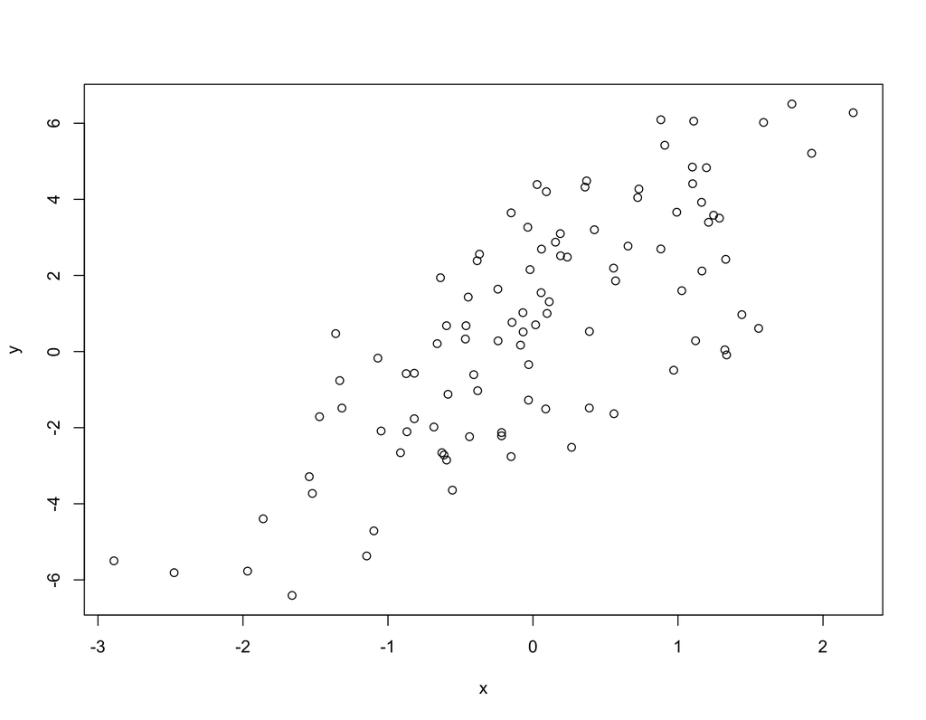

```r
plot(x, y)
```

### logistic regression

```r
set.seed(10)
x <- rbinom(100, 1, 0.5)
e <- rnorm(100, 0, 2)
y <- 0.5 + 2 * x + e
summary(y)
```

```
##    Min. 1st Qu.  Median    Mean 3rd Qu.    Max.
##  -3.490  -0.141   1.580   1.430   2.840   6.940
```

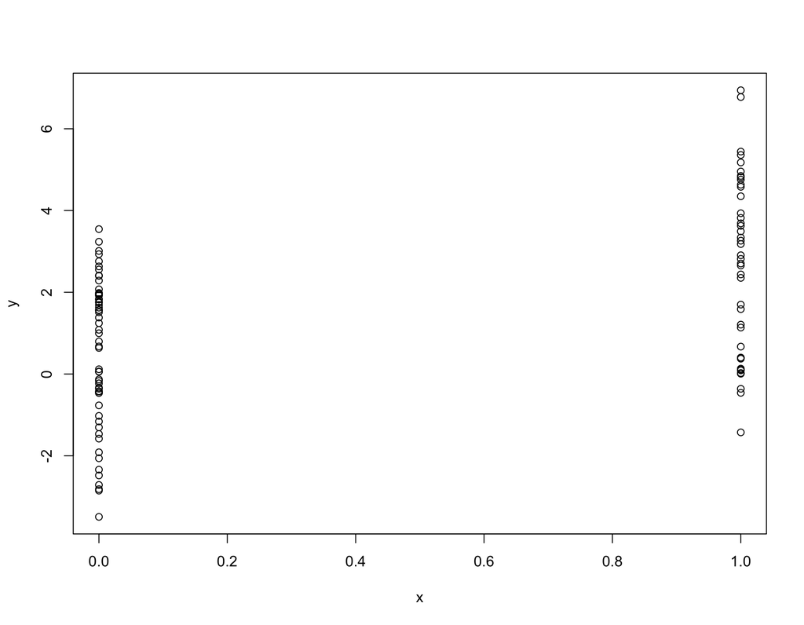

```r
plot(x, y)
```

### Count data

```r
set.seed(1)
x <- rnorm(100)
log.mu <- 0.5 + 0.3 * x
y <- rpois(100, exp(log.mu))
summary(y)
```

```
##    Min. 1st Qu.  Median    Mean 3rd Qu.    Max.
##    0.00    1.00    1.00    1.55    2.00    6.00
```

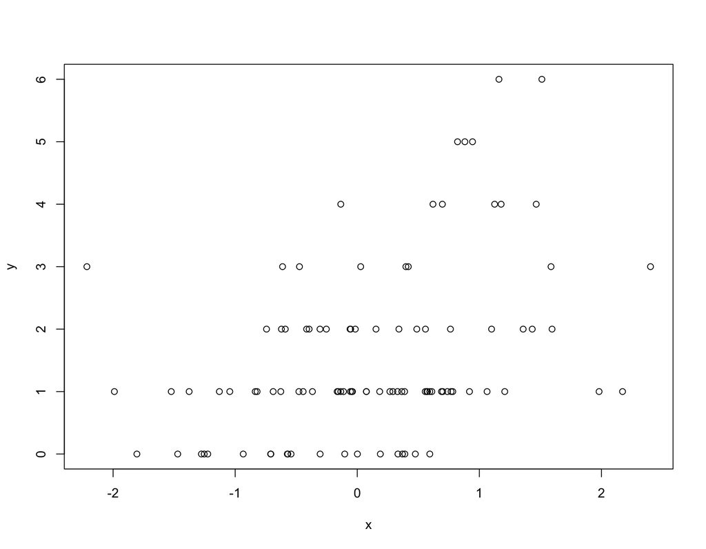

```r
plot(x, y)
```

## Sample function

- Draw a random from an object
- Ex. `sample(1:10, 4)`
- Can set `replace = TRUE` so that numbers from sample can be repeated

# R profiler

- Used for debugging/assessing code
- Helps to optimize code, find out if/why it is slow

## When and why?

- Typically **after** you have thought about written your code

## system.time()

- evaluates r expression
- user time: time the CPU needed to evaluate
- elapsed time: real, measured clock/wall time

## Rprof()

- this function starts the profiler in R
- `summaryRprof()` will summarize the output of `Rprof()`
- Don’t use at the same time as `system.time()`

### What does it do?

- It keeps track of the function call stack at regularly sampled intervals
- It then tabulates how much time is spent on each function
- “This called this, which called that, which called…”

### summaryRprof()

- “by.total” = divides the time spent on each function by the total run time
  - time spent in top level function, generally less interesting
- “by.self” = the same but first subtracts out time spent on functions above in the call stack
  - how much time spent in lower level functions, gives more accurate idea of what you should target to optimize

## Optimization

- optim, nlm, optimize
- require you to pass a function whose argument is a vector of parameters
- you can write a constructor function

Ex.

```r
set.seed(1); normals <- rnorm(100, 1, 2)
nLL <- make.NegLogLik(normals)
nLL

make.NegLogLik <- function(data, fixed = c(FALSE, FALSE)) {
    params <- fixed
    function(p) {
        params[!fixed] <- p
        mu <- params[1]
        sigma <- params[2]
        a <- -0.5 * length(data) * log(2 * pi * sigma^2)
        b <- -0.5 * sum((data-mu)^2) / (sigma^2)
        -(a + b)
    }
}
```

- Estimating parameters

```r
optim(c(mu = 0, sigma = 1), nLL)$par
```

- Fixing o = 2

```r
nll <- make.NegLogLik(normals, c(FALSE, 2))
optimize(nLL, c(-1, 3))$minimum
```

- Fixing u = 1

```r
nll <- make.NegLogLik(normals, c(1, FALSE))
optimize(nLL, c(1e-6, 10))$minimum
```

# Data resources

## Open government sites

- [UN data sets](http://data.un.org)
- [US](http://www.data.gov)
- [UK](http://data.gov.uk)
- [France](http://www.data.gouv.fr/)
- [Ghana](http://data.gov.gh)
- [Australia](http://data.gov.au)
- [Germany](https://www.govdata.de/)
- [Hong Kong](http://www.gov.hk/en/theme/psi/datasets/)
- [Japan](http://www.data.go.jp/)
- [more](http://www.data.gov/opendatasites)

## Non-governmental sites

- gapminder
- [Survey data](http://www.asdfree.com)
- [infochimp](http://www.infochimps.com/marketplace)
- [kaggle](http://www.kaggle.com)

## Researchers personal sites

- [Hilary Mason](http://bitly.com/bundles/hmason1/)
- [Peter Skomoroch](https://delicious.com/pskomoroch/dataset)
- [Jeff Hammerbacher](http://www.quora.com/Jeff-Hammerbacher/Introduction-to-Data-Science-Data-Sets)
- [Gregory Piatetsky-Shapiro](http://www.kdnuggets.com/gps.html)
- [Lists](http://blog.mortardata.com/post/67652898761/6-dataset-lists-curated-by-data-scientists)

## Specialized collections

- [Stanford Large Network Data](http://snap.stanford.edu/data/)
- [UCI Machine Learning](http://archive.ics.uci.edu/ml/)
- [KDD Nugets Datasets](http://www.kdnuggets.com/datasets/)
- [CMU Statlib](http://lib.stat.cmu.edu)
- [Gene expression omnibus](http://www.ncbi.nlm.nih.gov/geo/)
- [ArXiv Data](http://arxiv.org/help/bulk_data)
- [Public Data Sets on Amazon Web Services](http://aws.amazon.com/publicdatasets/)

## APIs

- **twitter** and `twitteR` package
- **figshare** and `rfigshare`
- **PLos** and `rplos`
- **rOpenSci**
- **Facebook** and `RFacebook`
- **Google maps** and `RGoogleMaps`

# Other useful packages

## Searching for relavant package

- “data storage mechanism” + R package
- ex. mySQL R package

## interacting with files

- file()
- url()
- gzfile()
- bzfile()
- ?connections
- foreign package
- read.XXX

## reading images (packages and functions)

- jpeg
- readbitmap
- png
- EBImage

## GIS data

- rdgal
- rgeos
- raster

## reading music data

- tuneR
- seewave

# Exploratory data analysis

## Six principles of analytic graphics

1. Show comparisons
   - Evidence for a hypothesis is always relative to another competing hypothesis
   - always ask “compared to what”?
2. Show causality, mechanism, explanation
   - What is your causal framework for thinking about a question?
3. Show multivariate data
   - Multivariate = more than 2 variables
   - the real world is multivariate
   - need to “escape flatland”
4. Integrate multiple modes of evidence
   - Completely integrate words, numbers, images, diagrams
   - Data graphics should make use of many modes of data presentation
   - Don’t let the tool drive the analysis
5. Describe and document the evidence
   - A data graphic should tell a complete story that is credible
6. Content is king
   - Analytical presentations ultimately stand or fall depending on the quality, relevance, and integrity of their content

## Exploratory graphs

- Graphs you make for yourself to get an idea of whats going on (understand data properties, find patterns, suggest modeling strategies, debug analysis)
- Goal = personal understanding

### Simple summaries of data (1 dimension)

- Five number summary
- Boxplots

```r
boxplot(pollution$mp25, col = "blue")
abline(h = 12)
```

- Histograms

```r
hist(pollution$pm25, col = "green", breaks = 100)
rug(pollution$pm25
abline(v = 12, lwd = 2)
abline(v = median(pollution$pm25), col = "magenta", lwd = 4)
```

- Density Plot
- Barplot

```r
barplot(table(pollution$region), col = "wheat", main = "Number of counties in each region")
```

- 2 dimensions
  - Multiple/overlayed 1d plots (lattice/ggplot2)
  - Scatterplots

```r
with(pollution, plot(latitude, pm25))
abline(h = 12, lwd = 2, lty = 2)

par(mfrow = c(1, 2), mar = c(5, 4, 2, 1))
with(subset(pollution, region == "west"), plot(latitude, pm25, main = "West"))
with(subset(pollution, region == "east"), plot(latitude, pm25, main = "East"))
```

- Smooth scatterplots
- > than 2d
- Overlayed/multiple 2d plots, coplots
- Use color, size, shape to add dimensions
- Spinning plots
- Actual 3d plot (not that useful)

## Plotting systems

### The base plotting system

- Artist palette model
- Use annotation functions to add/moddify (text, lines, points, axis)
- Mirrors thought process
- Cant go back, must plan in advance or start over
- Series of R commands

Ex.

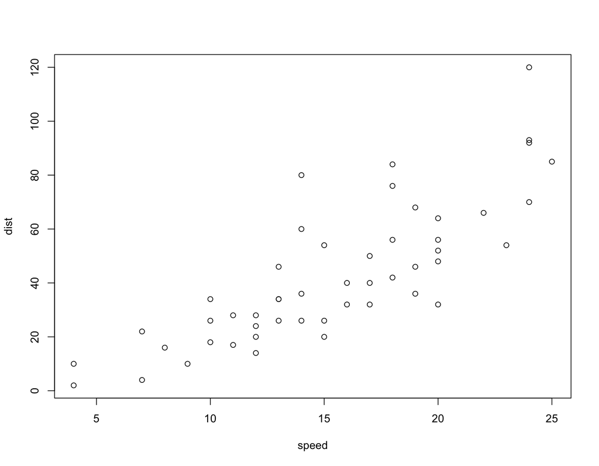

```r
library(datasets)
data(cars)
with(cars, plot(speed, dist))
```

- Generally graphing using **base** is a two step process…
  1. Initialize a new plot
  2. Annotate the existing plot
- There are *many* parameters (should try to memorize **?par**)

Ex.

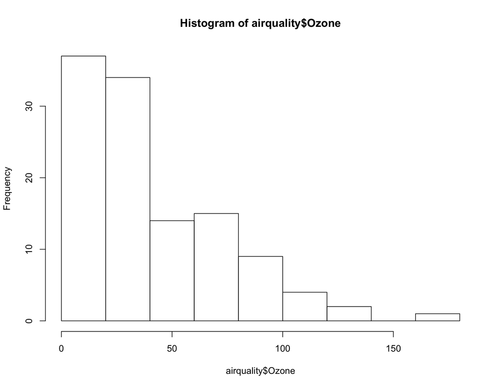

```r
library(datasets)
hist(airquality$Ozone)
```

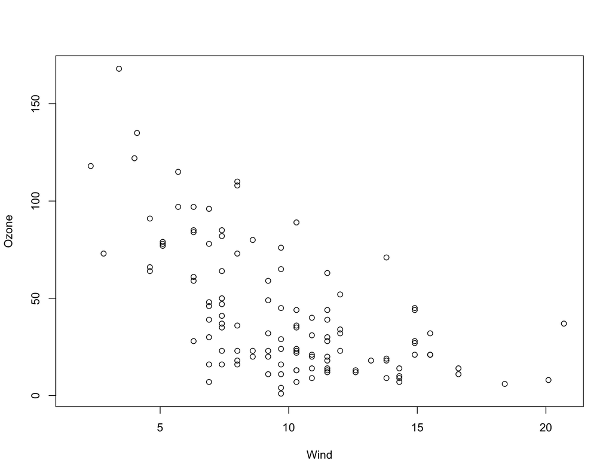

```r
with(airquality, plot(Wind, Ozone))
```

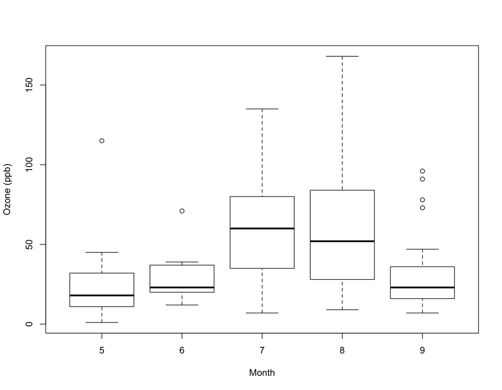

```r
airquality <- transform(airquality, Month = factor(Month))
boxplot(Ozone ~ Month, airquality, xlab = "Month", ylab = "Ozone (ppb)")
```

#### Key parameters

- **pch**: plotting symbol
- **lty**: line type
- **lwd**: line width
- **col**: plotting color
- **xlab**: x label (char string)
- **ylab**: y label (char string)
- **par()**: used to set global graphics parameters
  - **las**: orientation of the axis labels on the plot
  - **bg**: background color
  - **mar**: margin size
  - **oma**: outer margin size
  - **mfrow**: number of plots per row, column (filled row wise)
  - **mfcol**: number of plots per row, column (filled column wise)

#### Key plotting functions

- **plot**: scatterplot, or type of plot that makes sense for the class of the object being plotted
- **lines**: add lines to a plot, 2-column matrix, function connects the dots
- **points**: add points to a plot
- **text**: add text labels to a plot using specified x, y coordinates
- **title**: add annotations to x, y axis labels, title, subtitle, outer margin
- **mtext**: add arbitrary text to the margins (inner/outer) of the plot
- **axis**: add axis ticks/labels

Ex. Base plot with annotation

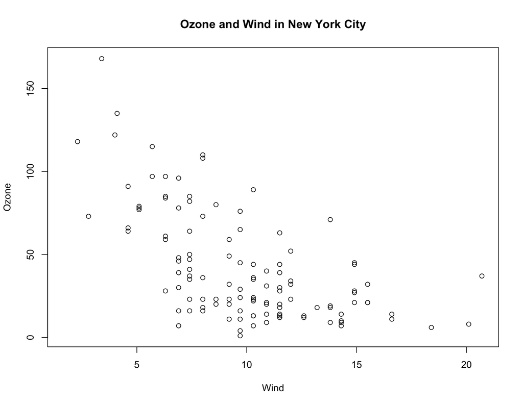

```r
library(datasets)
with(airquality, plot(Wind, Ozone))
title(main = "Ozone and Wind in New York City")
```

Ex. Base plot with subset and coloring

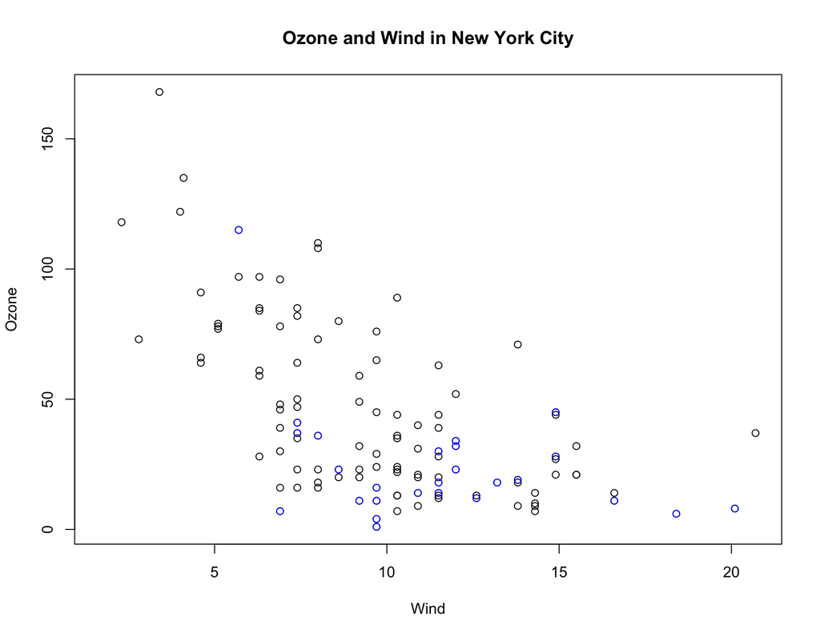

```r
library(datasets)
with(airquality, plot(Wind, Ozone, main = "Ozone and Wind in New York City"))
with(subset(airquality, Month == 5), points(Wind, Ozone, col = "blue"))
```

Ex. Base plot with more subsetting and coloring

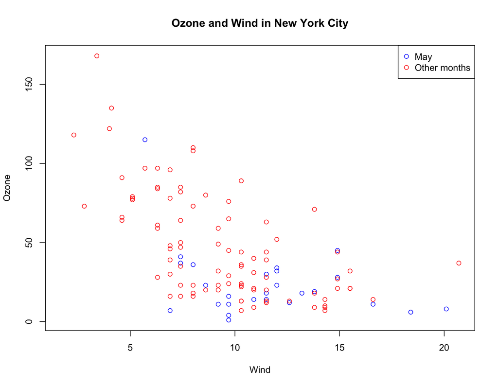

```r
library(datasets)
with(airquality, plot(Wind, Ozone, main = "Ozone and Wind in New York City", type = "n"))
with(subset(airquality, Month == 5), points(Wind, Ozone, col = "blue"))
with(subset(airquality, Month != 5), points(Wind, Ozone, col = "red"))
legend("topright", pch = 1, col = c("blue", "red"), legend = c("May", "Other months"))
```

Ex. Base plot with regression line

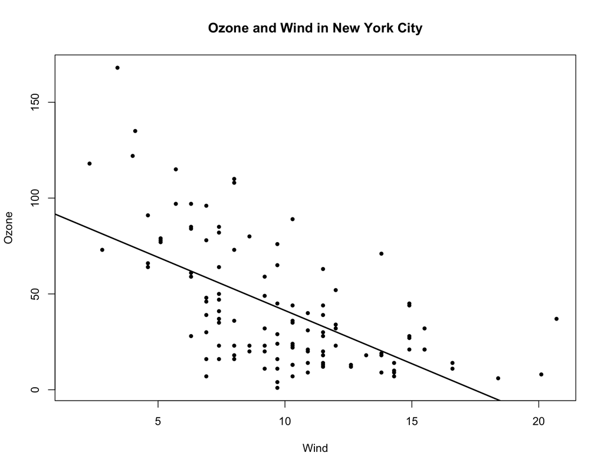

```r
library(datasets)
with(airquality, plot(Wind, Ozone, main = "Ozone and Wind in New York City", pch = 20))
model <- lm(Ozone ~ Wind, data = airquality)
abline(model, lwd = 2)
```

Ex. Multiple base plots

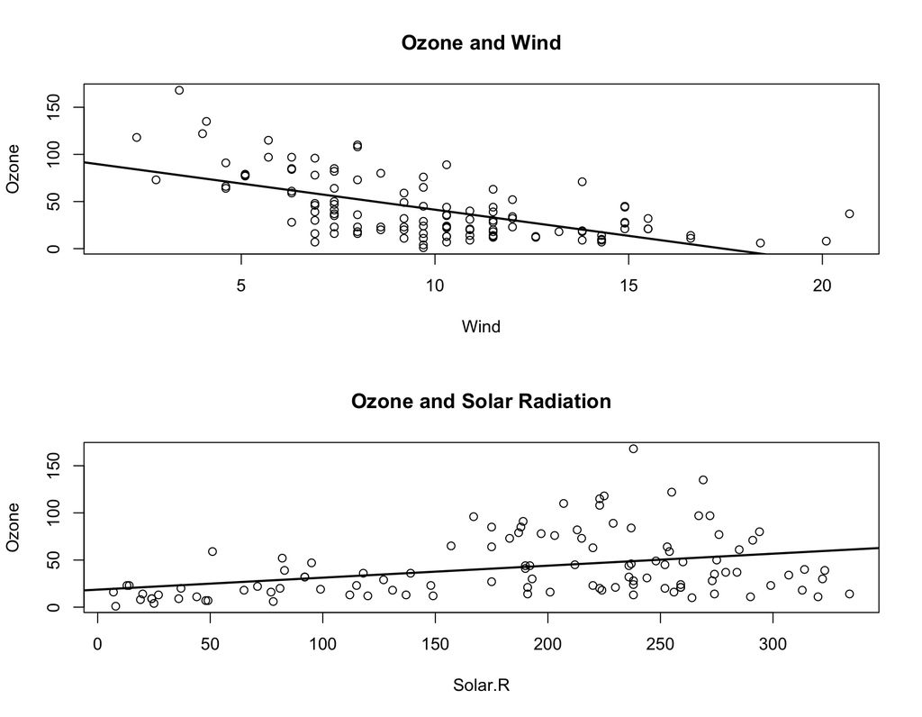

```r
library(datasets)
model1 <- lm(Ozone ~ Wind, data = airquality)
model2 <- lm(Ozone ~ Solar.R, data = airquality)
par(mfrow = c(2, 1))
with(airquality, {
    plot(Wind, Ozone, main = "Ozone and Wind")
    abline(model1, lwd = 2)
    plot(Solar.R, Ozone, main = "Ozone and Solar Radiation")
    abline(model2, lwd = 2)
})
```

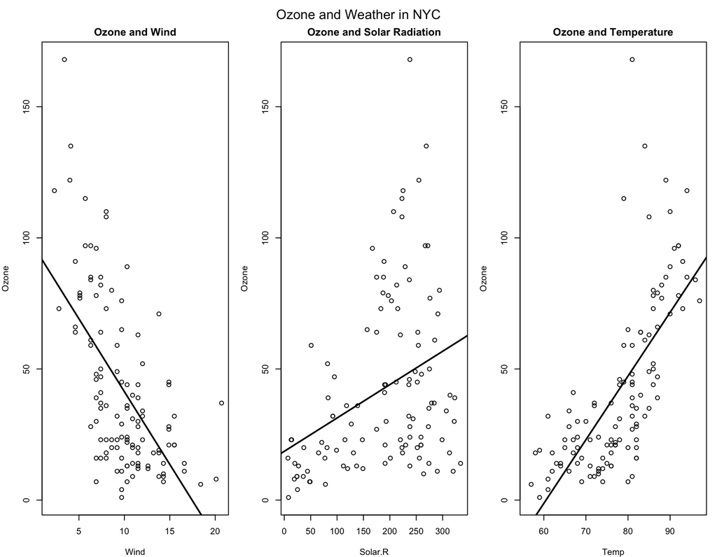

```r
library(datasets)
model1 <- lm(Ozone ~ Wind, data = airquality)
model2 <- lm(Ozone ~ Solar.R, data = airquality)
model3 <- lm(Ozone ~ Temp, data = airquality)

par(mfrow = c(1, 3), mar = c(4, 4, 2, 1), oma = c(0, 0, 2, 0))
with(airquality, {
    plot(Wind, Ozone, main = "Ozone and Wind")
    abline(model1, lwd = 2)
    plot(Solar.R, Ozone, main = "Ozone and Solar Radiation")
    abline(model2, lwd = 2)
    plot(Temp, Ozone, main = "Ozone and Temperature")
    abline(model3, lwd = 2)
    mtext("Ozone and Weather in NYC", outer = TRUE)
})
```

Ex. Testing it out on my own…

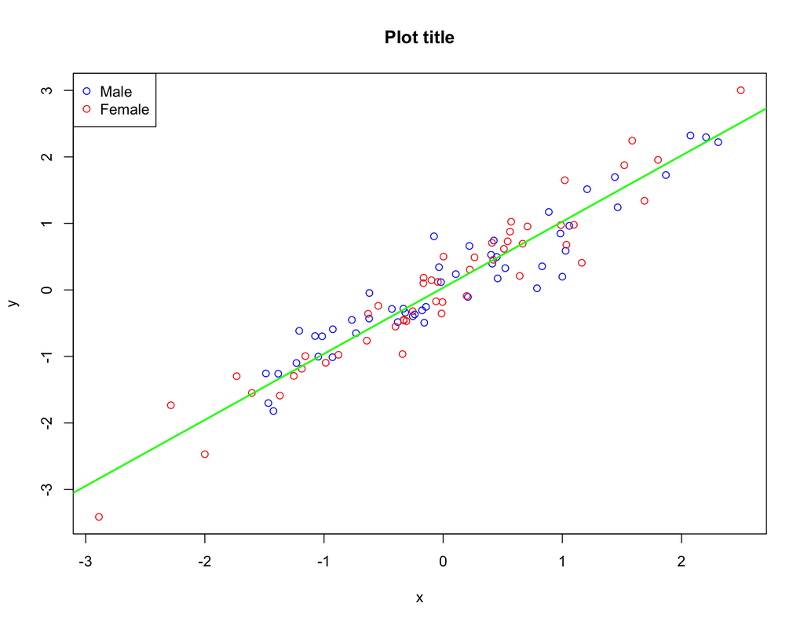

```r
x <- rnorm(100)
y <- x + rnorm(100)/3
g <- gl(2, 50, labels = c("Male", "Female"))
fit <- lm(y ~ x)

plot(x, y, type = "n")
points(x[g == "Male"], y[g == "Male"], col = "blue")
points(x[g == "Female"], y[g == "Female"], col = "red")
abline(fit, lwd = 2, col = "green")
legend("topleft", legend = c("Male", "Female"), pch = 1, col = c("blue", "red"))
title("Plot title")
```

#### Graphics devices

- something you can use to make a plot appear
  - a window
  - a pdf file
  - a png or jpg file
  - a scalable vector graphics (SVG) file
- Plots have to be sent to a graphics device (most common is a screen device)
- Vector formats
  - pdf: useful fore line-type graphics, resizes well, usually portable, not efficient if a plot has many objects/points
  - svg: xml-based scalable vector graphics, suuposrt animation and interactivity, potentially useful for web-based plots
  - win.metafile: only for windows
  - postscript: older format, also resizes well, predecesor to pdf
- Bitmap formats
  - png: bitmapped format good for drawing lines and images with solid colors, good for plots with many points
  - jpeg: does not resize well
  - tiff: supports lossless compression
  - bmp: windows
- Copying plots
  - make a plot with screen device, then save it
  - **dev.copy**: copy a plot form one device to another
  - **dev.copy2pdf**: specifically copy a plot to a pdf file

Ex. code

```
library(datasets)
with(faithful, plot(eruptions, waiting)) # create plot
dev.copy(png, file = "testplot.png") # copy plot in screen device to a png file
dev.off() # close png device
```

### The Lattice system

- Plots constructed with function call (xyplot, bwplot)
- Useful for conditioning plots, panel plots
- Details set automatically because plot is specified at once
- Cannot add to plot once it is generated
- Main functions
  - **xyplot()**: main function for scatterplots
  - **bwplot()**: box and whisker plot, boxplot
  - **histogram()**: histograms
  - **stripplot()**: like bwplot, but with points
  - **dotplot()**: dots on violin strings
  - **splot()**: scatterplot matrix
  - **levelplot(), contourplot()**: for image data
- Normally use a formula for first argument
- Lattice returns an object of class trellis and this object is autoprinted
  - You can verify this by giving a trellis object a variable (i.e. `p <-`) and then printing said object (i.e. `print(p)`)
  - This differs from when you do not assign the object to a variable (it is autoprinted)

```
xyplot(y ~ x | f * g, data = )
```

Ex. Basic scatterplot

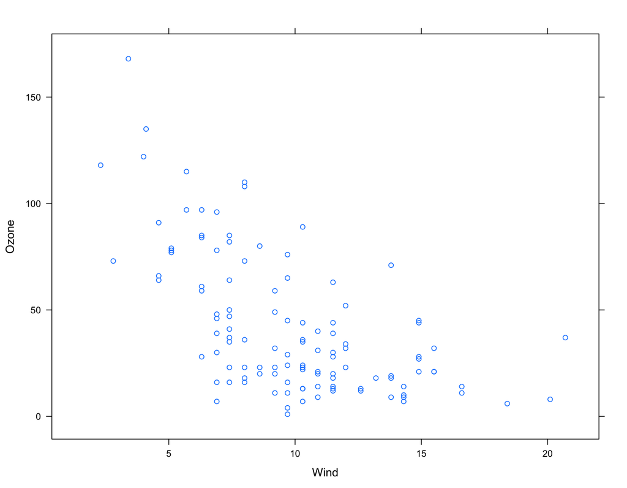

```r
library(lattice)
library(datasets)
xyplot(Ozone ~ Wind, data = airquality)
```

Ex. Scatterplot at distinct levels

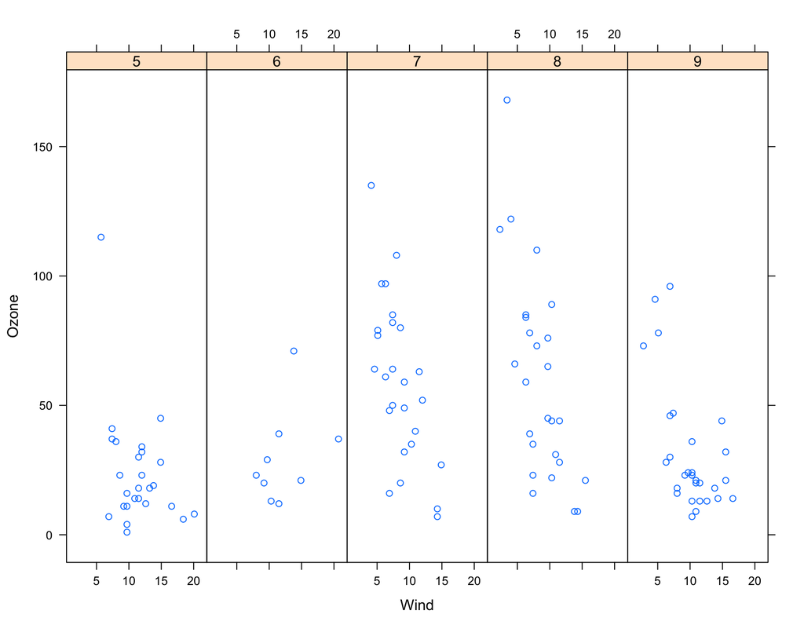

```r
library(datasets)
library(lattice)
airquality <- transform(airquality, Month = factor(Month))
xyplot(Ozone ~ Wind | Month, data = airquality, layout = c(5, 1))
```

Ex.

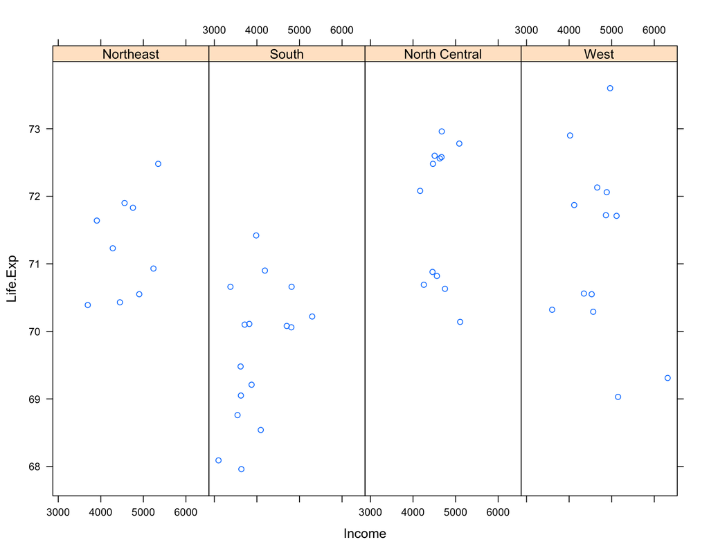

```r
library(lattice)
state <- data.frame(state.x77, region = state.region)
xyplot(Life.Exp ~ Income | region, data = state, layout = c(4,1))
```

- Panel fucntions
  - these control what happens inside each panel of the plot
  - there are default settings, they can be customized
  - they receive the x/y coordinates of the data points in their panel

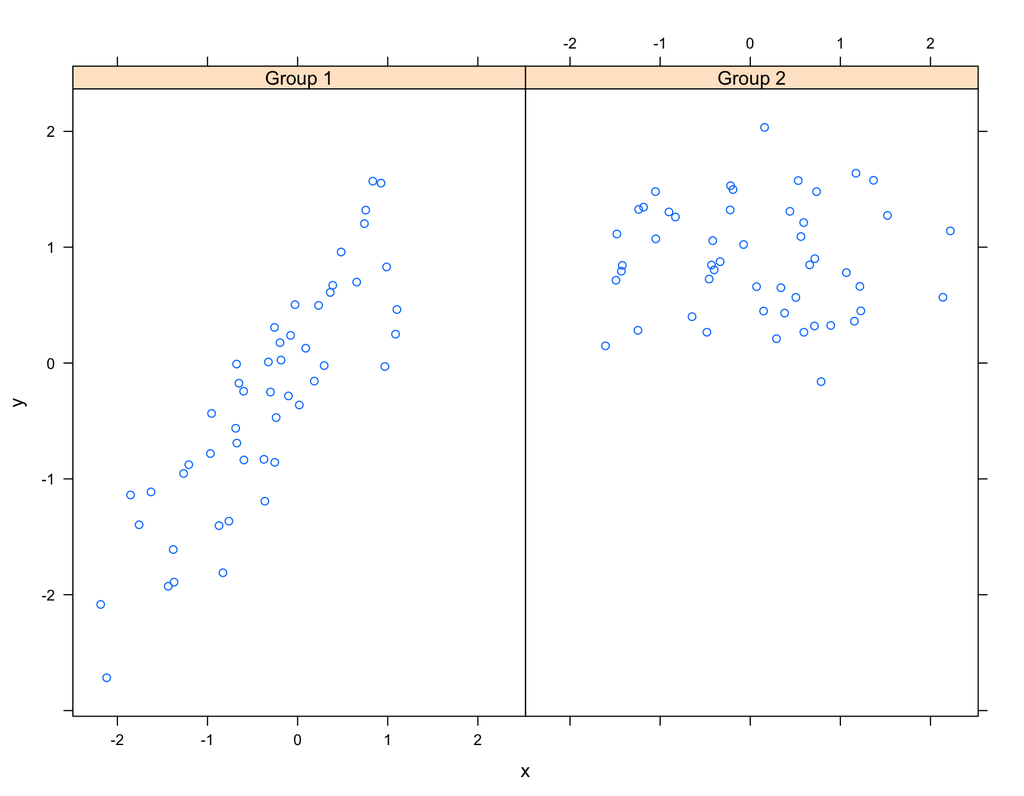

```r
set.seed(10)
x <- rnorm(100)
f <- rep(0:1, each = 50)
y <- x + f - f * x + rnorm(100, sd = 0.5)
f <- factor(f, labels = c("Group 1", "Group 2"))
xyplot(y ~ x | f, layout = c(2, 1))
```

Ex. W/ custom panel function (median line)

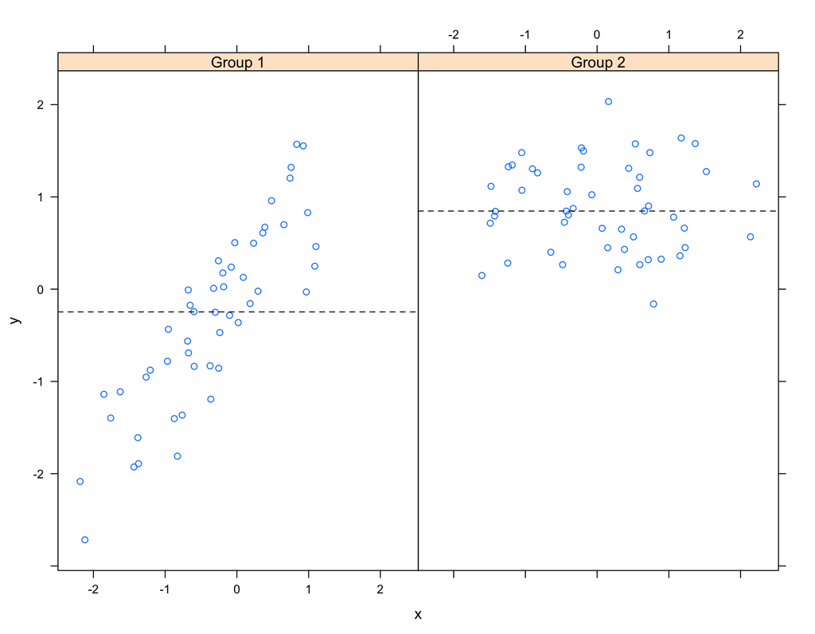

```r
set.seed(10)
x <- rnorm(100)
f <- rep(0:1, each = 50)
y <- x + f - f * x + rnorm(100, sd = 0.5)
f <- factor(f, labels = c("Group 1", "Group 2"))
xyplot(y ~ x | f, panel = function(x, y, ...) {
    panel.xyplot(x, y, ...) # call default panel function to plot points
    panel.abline(h = median(y), lty = 2) # add horizontal line at median
})
```

Ex. W/ custom panel function (regression line)

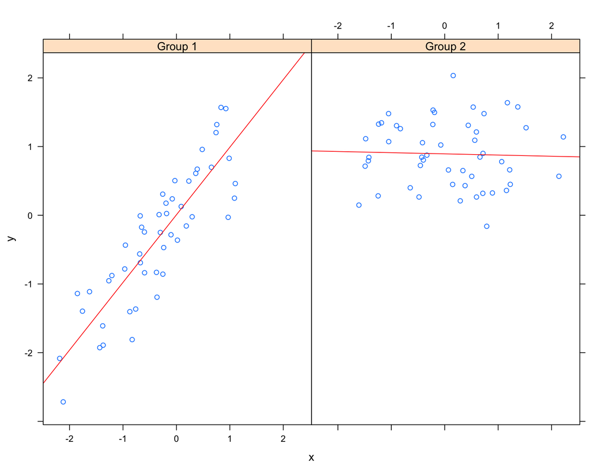

```r
set.seed(10)
x <- rnorm(100)
f <- rep(0:1, each = 50)
y <- x + f - f * x + rnorm(100, sd = 0.5)
f <- factor(f, labels = c("Group 1", "Group 2"))
xyplot(y ~ x | f, panel = function(x, y, ...) {
    panel.xyplot(x, y, ...) # call default panel function to plot points
    panel.lmline(x, y, col = 2) # add simple lm line
})
```

### ggplot2

- Splits difference between base and lattice
- Aesthetics calculated at once
- Superficially similar to lattice but more intuitive

Ex.

```
## geom_smooth: method="auto" and size of largest group is <1000, so using loess. Use 'method = x' to change the smoothing method.
```

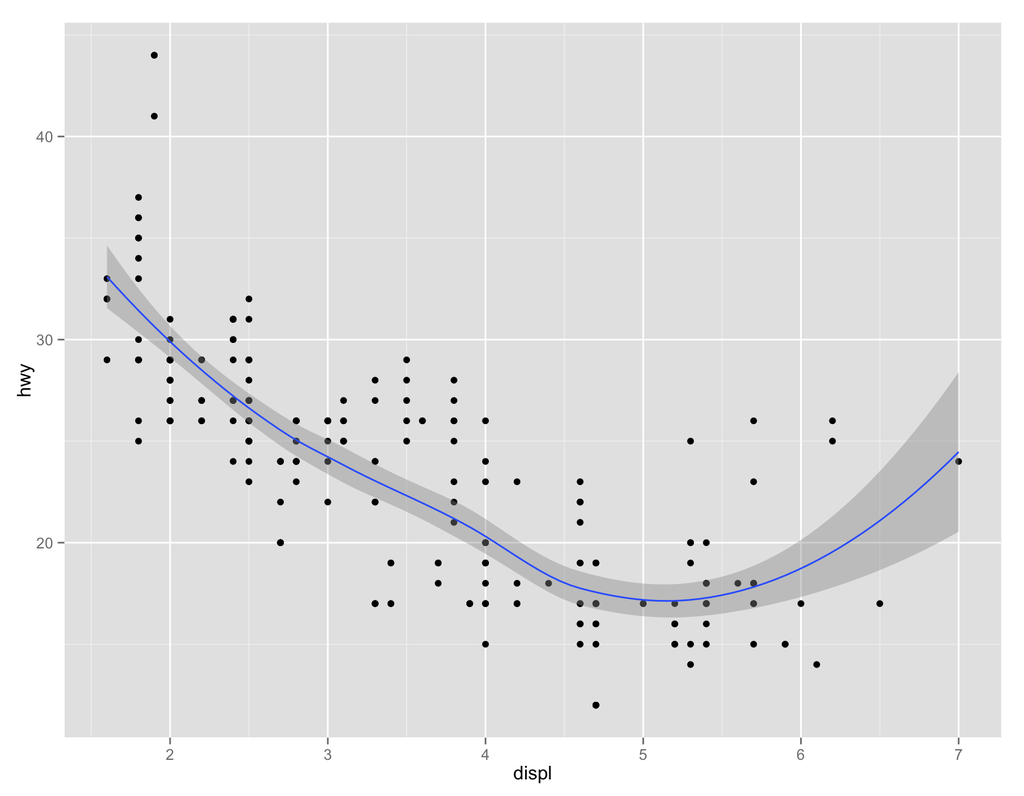

[output not shown]

```r
library(ggplot2)
data(mpg)
qplot(displ, hwy, data = mpg) + geom_smooth()
```